# final project

5/5/2018

## About & Methodology

This research project aims to use twitter collected data from the following model: AdrianaLima, MarthaHunt, bellahadid, GiGiHadid, and KendallJenner.

Using the data we will look at: - the frequency of hashtag of model - model post of the past month - Comparing the ratio of follower to friends of these model

## Adriana Lima Frequency chart

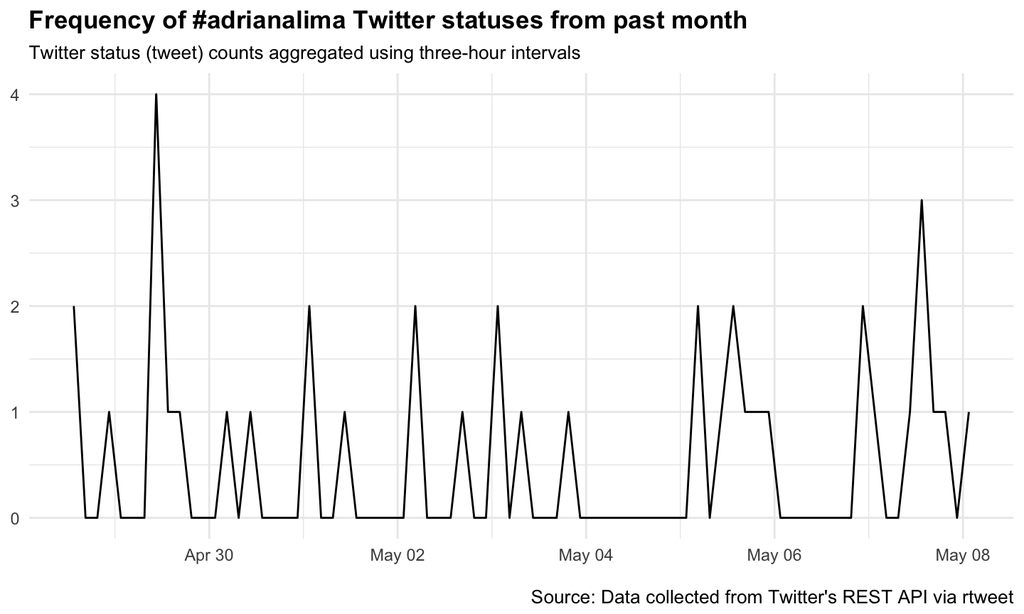

## Martha Hunt Frequency chart

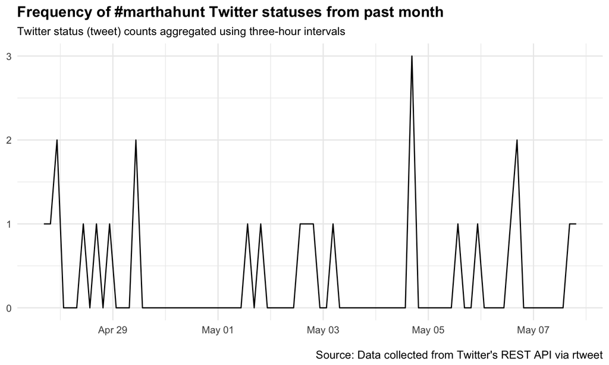

## Bellahadid Frequency Chart

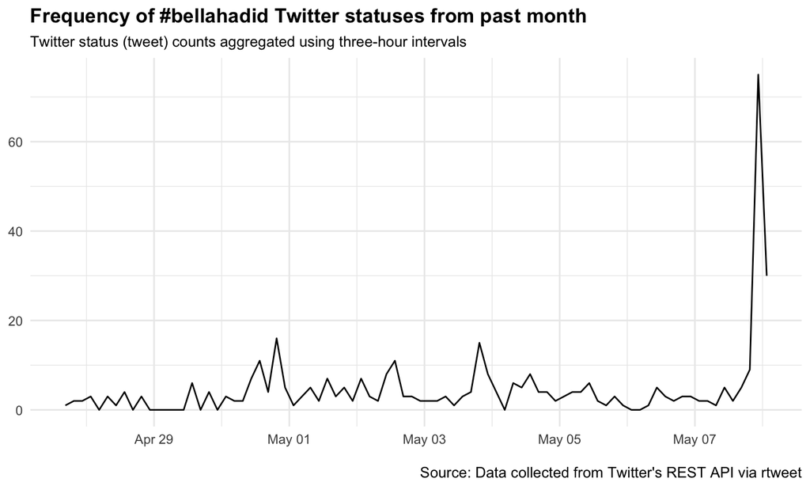

## Gigi Haldid Frequency Chart

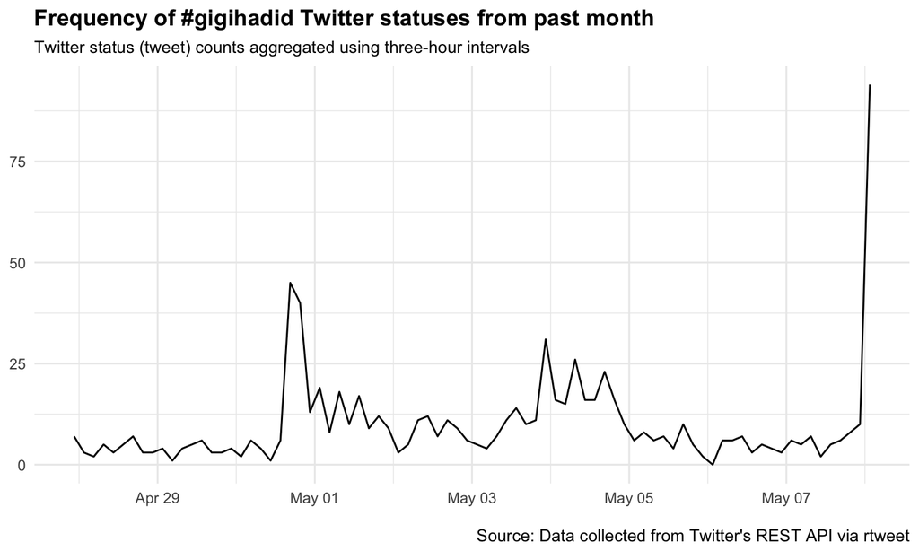

## Kendall Jenner Frequency Chart

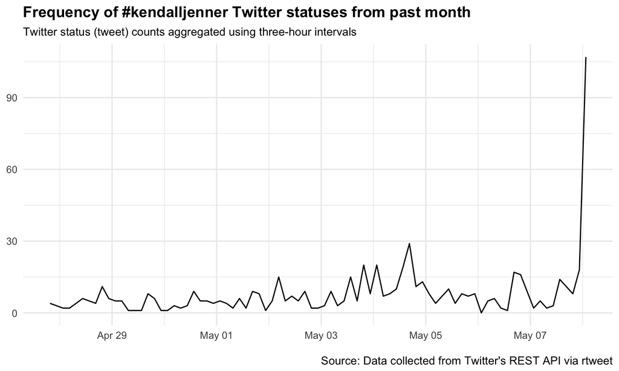

## Observations

Looking at charts, we often see there being sudden peaks in the number of hashtags used on twitter. If we google those dates, it is often seen that the model was doing photoshot or attending an event that appeared on the news.

[figure not shown]

## Observations 2

From the frequency of post, we can see that most post peaks correlates to the photoshot and events from the hashtag charts. Though except for one exception as clearly see as outlier (Martha Hunt's tweet explosion around November 2017) - This is when Martha Hunt attended the VS show and tweeted from behind the screen non-stop.

## Follower compared to friends table

```
##                AdrianaLima MarthaHunt bellahadid GiGiHadid KendallJenner
## follower count     2879712     457133    1014582   9185286      26888517
## friends count          139        301        148       582           134
```